# Exploratory Data Analysis of Known Exoplanets by Luke Tibbott

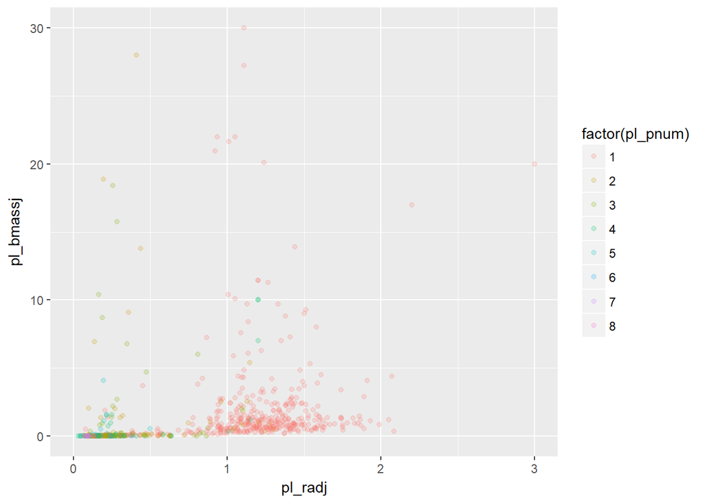

Planets that are part of a system with only one planet tend to have higher radius than those that have multiple planets in their system. Could this mean that terrestrial planets (which have lower radius than gaseous planets) are more likely to be part of systems with multiple planets?

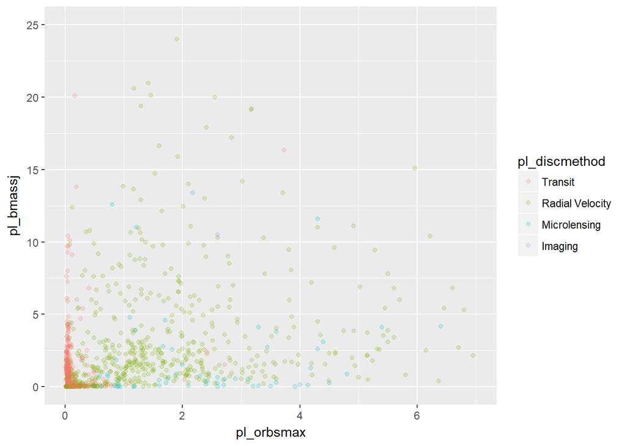

The transit method doesn’t discover many planets that are rotating more than 0.5 AU from their host star. These planets tend to lie on a vertical line around 0 AU. Let’s investigate the properties of planets discovered by transit in the next plot!

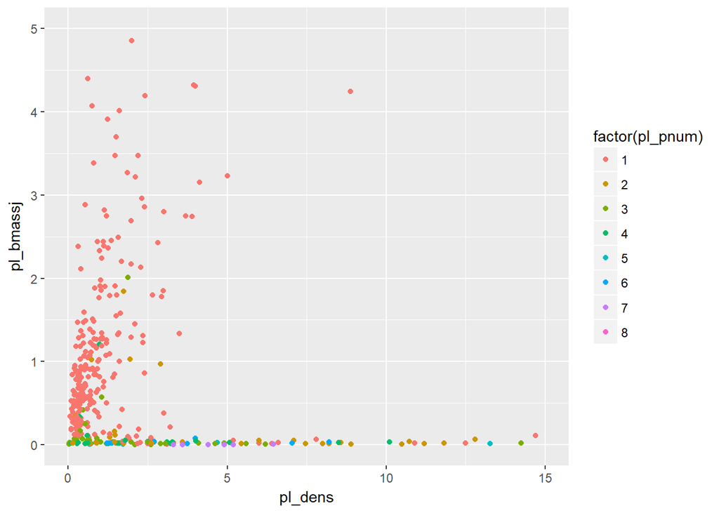

Planets that have high mass, low density and that are part of systems with only one planet are seen on the left side of this plot. Planets with higher density and lower mass hug the x-axis.

```
##
## Call:
## lm(formula = pl_bmassj ~ pl_radj + pl_dens, data = ep)
##
## Residuals:
##      Min       1Q   Median       3Q      Max
## -16.1552  -0.7534  -0.1937   0.3583  20.6315
##
## Coefficients:
##             Estimate Std. Error t value Pr(>|t|)
## (Intercept) -1.37890    0.25676  -5.370 1.37e-07 ***
## pl_radj      2.20523    0.22921   9.621  < 2e-16 ***
## pl_dens      0.22387    0.02231  10.034  < 2e-16 ***
## ---
## Signif. codes:  0 '***' 0.001 '**' 0.01 '*' 0.05 '.' 0.1 ' ' 1
##
## Residual standard error: 2.132 on 379 degrees of freedom
##   (3314 observations deleted due to missingness)
## Multiple R-squared:  0.2755, Adjusted R-squared:  0.2716
## F-statistic: 72.04 on 2 and 379 DF,  p-value: < 2.2e-16
```

This linear model accounts for only 27.2% of the variance of planetary mass! We will explore this in the multivariate analysis section.

# Multivariate Analysis

### Talk about some of the relationships you observed in this part of the investigation. Were there features that strengthened each other in terms of looking at your feature(s) of interest?

Radius, mass, and density generally behaved as predicted. As radius increases, so does mass, while density decreases. As mass increases, density also increase, and so does radius.

Among planets discovered via the transit method, one group of planets has low density, high mass, and only one planet in their system. The other (smaller) group of planets has higher density, much lower mass, and more planets in their system. I believe these two groups represent hot Jupiters and terrestrial planets respectively.

Planets discovered via transit tend to be a moderate distance from earth (100 to 2000 light years away), have relatively low mass, and orbit close to their star.

Planets discovered via microlensing tend to be very far from earth (> 2000 light years), and have low mass.

### Were there any interesting or surprising interactions between features?

I’m surprised different discovery methods yield such distinct types of planets. There is some overlap between radial velocity and imaging, but the other discovery methods have clear strengths and weaknesses in their ability to discovery planets.

### OPTIONAL: Did you create any models with your dataset? Discuss the strengths and limitations of your model.

$$\begin{equation}
volume = \frac{4}{3}\pi{r}^{3}\\
density = \frac{mass}{volume}
\end{equation}$$

Which leads us to conclude

$$\begin{equation}
mass = density*volume\\
mass = {density}*\frac{4}{3}\pi{r}^{3}
\end{equation}$$

However, this is not a linear definition of mass (rather, it is cubic). Our *linear* model is not set up to predict mass in this way. If mass were written as a linear combination of density and volume, our linear model would be much better.

Perhaps more importantly, there are a few distinct groups of planets in our dataset. Within these groups, I would expect a linear model to be much more accurate than our current model. However, when we consider the dataset as a whole, we get a rather low correlation coefficient.

# Final Plots and Summary

### Plot One

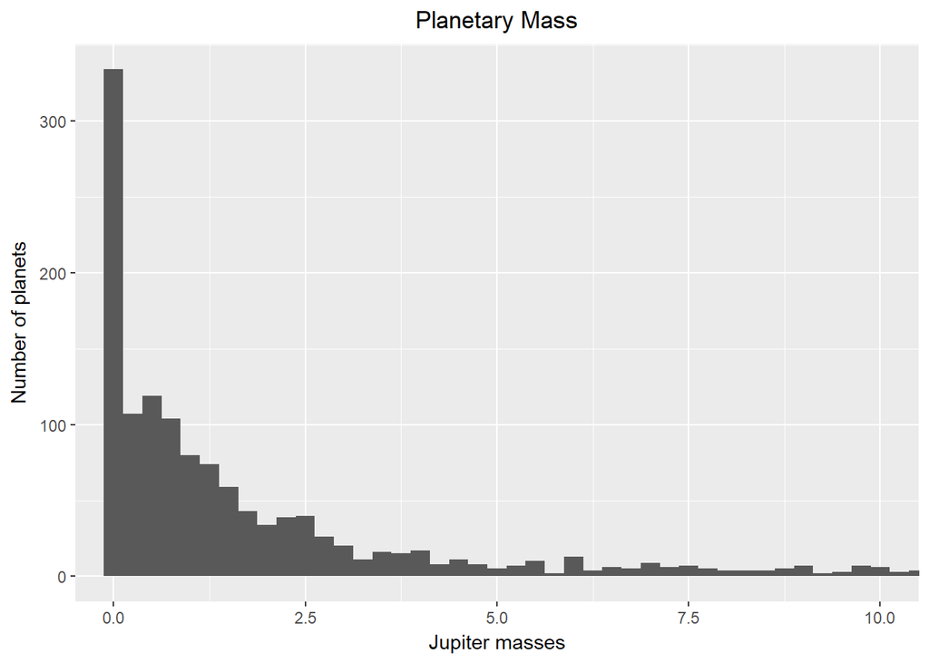

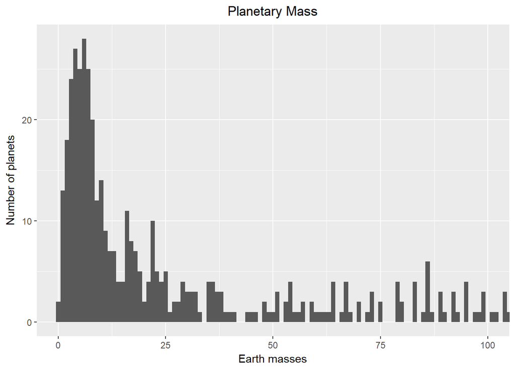

### Description One

The first plot shows us planets’ distribution of mass on a larger scale (eg we can see very low mass planets and high mass planets in this plot). The second plot shows us very low mass planets.

The second plot looks at the distribution of planets in terms of earth masses. The large spike near 0 Earth masses is almost certainly composed entirely of terrestrial planets.

### Plot Two

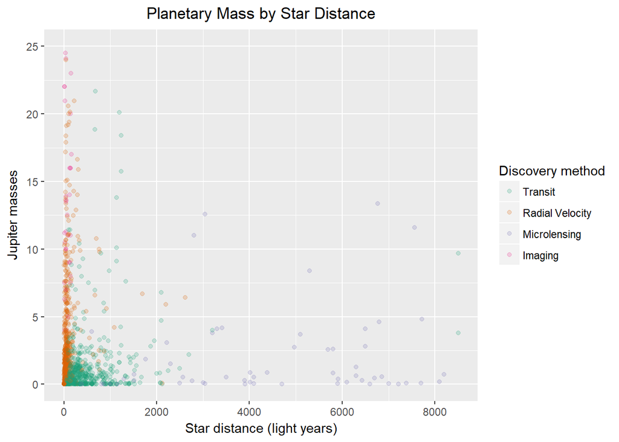

### Description Two

This plot allows us to see the strengths and limitations of the most common discovery methods in regards to planetary mass and distance from earth.

- Radial velocity appears to be biased towards discovering planets near earth and with any mass from 0 to 20 Jupiter masses.
- Transit most easily discovers planets between 100 and 1500 light years from earth, with lower mass – below 2.5 Jupiter masses.
- Microlensing accounts for almost all planets discovered at a distance greater than 2000 light years away from earth.
- Imaging appears to be biased towards planets near earth with high mass.

### Plot Three

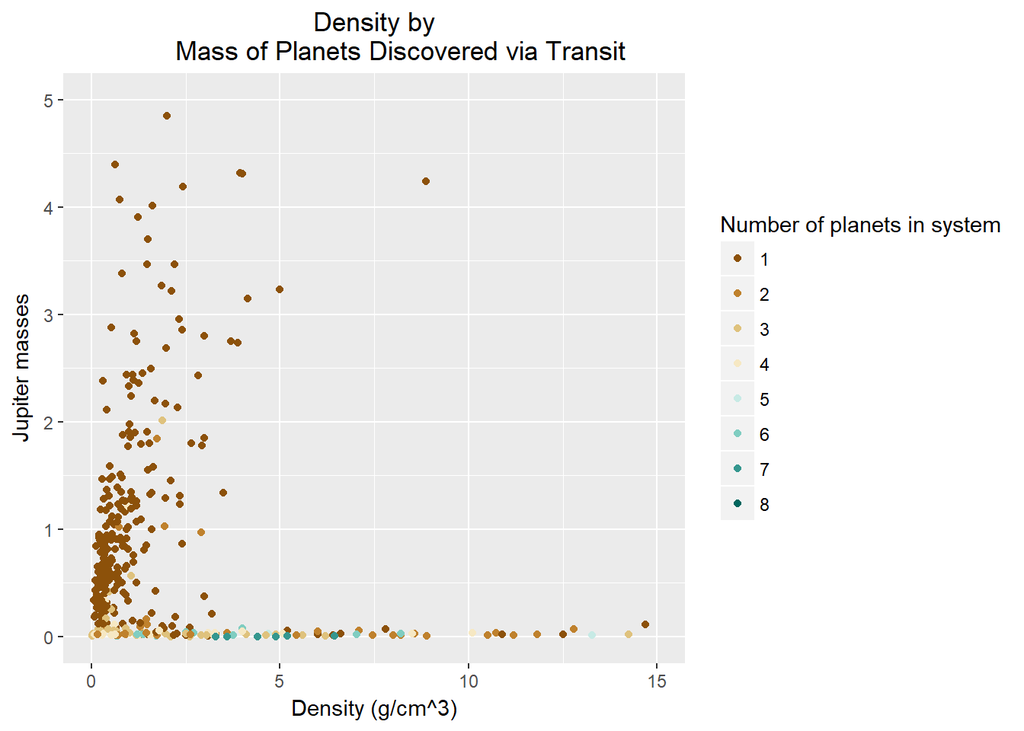

### Description Three

We can also see that planets with only one planet in the system tend to have higher mass than those with more than one planet in the system. This lends support to the theory that terrestrial planets tend to have more planets in their systems, while gas giants have fewer.

# Reflection

The data on exoplanets was accumulated between 1992 and 2018, with most of the planets being discovered after 2008. There are 3736 observations with 142 variables. I pared this down to 3696 observations with 17 variables after cleaning.

The study and discovery of exoplanets is an extremely exciting field right now! We’re in the early stages of this field, and have very few data points compared to how many planets likely exist in our galaxy, let alone the universe. Scientific methods may be able to approximate that average characteristics of planets, but our current dataset is not enough to make large generalizations of the distribution of any features of exoplanets.

For example, we could not say that there are more planets with high mass near earth than far from earth, despite our data clearly showing that trend. Our methods for discovering planets near earth appear to be somewhat biased towards discovering high mass planets, and our methods for discovering planets far from earth tend not to be biased towards discovering high mass planets.

This dataset suffers from lots of missing null values due to the data being from several different sources (eg different exoplanet discovery missions). I left all the nulls in tact and went ahead with my analysis. This was a constant limitation in this exploration.

One thing I’d love to do in the future with this dataset is to implement an algorithm that predicts what method a planet is likely to be discovered by given a few of the planets hypothetical parameters. I believe this could be implemented by a multinomial logistic regression model.